# Exploring Visibility Graphs to Route Seals Around Land

Josh M London

10/30/2020

```r
library(tidyverse)
library(DBI)
library(odbc)
library(sf)
library(lwgeom)
library(ggspatial)
library(glue)
library(here)
```

## Introduction

Routing marine mammal (and other marine taxa) telemetry tracks around water has been an issue on the wish list of bio-loggers for many years now. A number of approaches have been pursued over the years. But, many have either required censoring/cherry-picking of data OR extensive computational time. Here, we rely on routing technologies that many of us use daily when we query our phones for directions from point A to point B. In brief, a network of nodes and edges are created that represent possible paths through water (and, around land) within the study area. This graph is then used to determine the shortest path between two points through the network. The hope/intention is to make this process fast so hundreds of tracks can be re-routed around land in just a few minutes or, even, seconds.

This concept is often referred to as a ‘visibility graph’. Essentially, instead of a graph that represents routes from any node to every other node through unconstrained space, a visibility graph limits the graph connectivity to only those paths that are not blocked by a barrier. In the simplest of forms, we would start with a polygon representing our land barrier and extract all of the vertices as points. Then, we connect every vertex to every other vertex with a straight line. If we remove all of the lines that cross our land barrier, we are left with a network of ‘edges’ that only exist outside of the land barrier. This approach works when the land polygons are simple and the scale is relatively small. But, because we are connecting every vertex to every other vertex, the network complexity increases dramatically as more points are added.

If we have any hope of a solution that is scalable and computationally efficient, we need a better solution for building our network of edges that traverse around land. For this, we will turn to Delaunay Triangles. Delaunay triangles are commonly used for the creation of meshes to describe a surface. One advantage is that smaller (denser) triangles are created in areas with more information and areas with less information have larger triangles. In our situation, a complicated land barrier with inlets, islands, bays, fjords, etc would result in more detailed triangulation but larger open areas of water would contain fewer. If we think of each line in a triangle as an edge in our network, then we end up with a network that naturally represents the detail we need while minimizing the network size and complexity. The final step is to, simply, remove all of the lines/edges that are wholely within or that cross our barrier polygon.

To our knowledge, this network/graph approach has not been applied to the movement of marine animals. The approach we outline here (and pending development within the ‘pathroutr’ package) is intended to be used in conjunction with a predicted track output from a movement model (e.g. from the R package `{crawl}`). Additional advancements might incorporate this network approach into the statistical model fitting process.

This document explores the available functionality within existing R packages (e.g. `{igraph}`, `{sfnetworks}`). We setup an initial proof of concept within a PostgreSQL databse with both the PostGIS and pgRouting extensions installed. Then, we will work to port the same approach to an R-centric workflow. It is important to note that this problem is uniquely suited for many of the advantages a spatial database provides. Therefore, while we may find an R-centric solution, the best, most-efficient approach may still be to rely on a spatial database.

## Creating A Testing Space

Our first step is load in a set of polygons that will represent our *land barrier* and a set of points that will represent our potential starting and ending points. We’ve created these to be somewhat representative (but still simple enough for testing) of a real world environment we might encounter with actual movement data from a seal or other marine mammal. Our approach will be to test implementation of our code by randomly selecting a set of points as origin and destination features for our routing. Repeated selection of OD points will allow robust testing.

The polygons represented here are loosely based on islands present off the north end of Kodiak Island in Alaska. The set effectively represents inlets, bays, straits and island features of varying size that are typical of the coastal marine environment and are also typically challenging for routing.

```r
land_barrier <- sf::st_read(here::here('inst/extdata/simple_land_barrier.gpkg')) %>%
  st_transform(3338)
poi <- sf::st_read(here::here('inst/extdata/points_of_interest.gpkg')) %>%
  st_transform(3338)
```

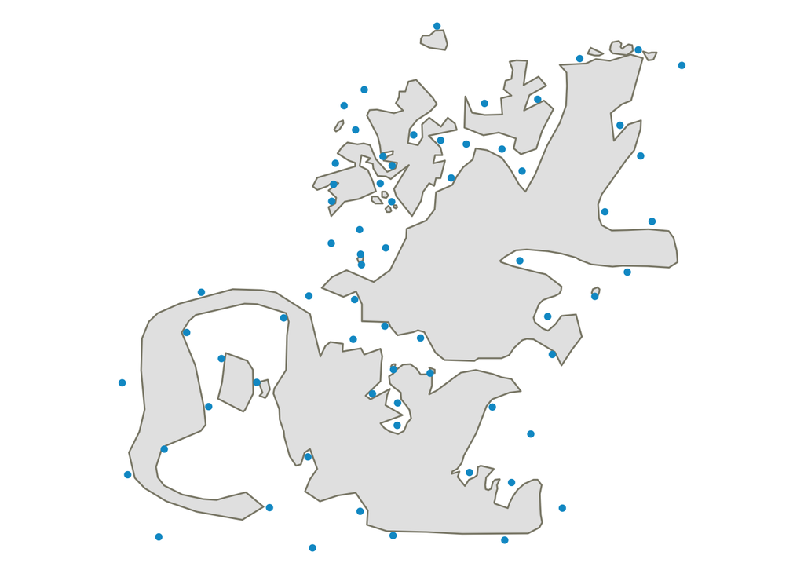

```r
ggplot() +
  ggspatial::annotation_spatial(land_barrier, color = "cornsilk4") +
  ggspatial::layer_spatial(poi, color = "deepskyblue3") +
  theme_void()
```

## PostGIS/pgRouting Solution

The PostgreSQL database extensions PostGIS and pgRouting offer a full set of spatial and network routing functions that we can take advantage of to prove our concept that this is a viable approach. The ultimate goal, however, is to provide a solution with R.

In this next code chunk, we setup our connection to the local database and push our `land_barrier` polygon up to the database while also creating a spatial index.

```r
con <- dbConnect(
  odbc(),
  dsn = "PostgreSQL localhost",
  maxvarcharsize = 0
)

st_write(land_barrier, con, "land_barrier", layer_options = "OVERWRITE=true")
```

```
## Note: method with signature 'DBIObject#sf' chosen for function 'dbDataType',
##  target signature 'PostgreSQL#sf'.
##  "OdbcConnection#ANY" would also be valid
```

```r
dbExecute(con,
"CREATE INDEX land_barier_gist ON land_barrier USING GIST (geometry)")
```

Now, we’re ready to build our network. The steps are pretty straight forward: extract all of the vertices from the polygon as points and create a geometry of Delaunay triangles from those points.

```sql
DROP TABLE IF EXISTS tri_routes;
CREATE TABLE tri_routes as
WITH land_pts AS (
SELECT (ST_DumpPoints(geometry)).geom geometry FROM land_barrier)
SELECT (ST_Dump(ST_DelaunayTriangles(ST_Collect(land_pts.geometry), 0,1))).geom geometry
FROM land_pts;
```

Now, we need to turn this series of lines into network that is built only from those lines that are not within or do not cross the `land_barrier` polygons. In addition to the spatial query we also need to set of nodes and edges based on our lines. The endpoints of each line represents our nodes and the edges are, obviously, the lines. So, all of the spatial information we need is there. But, a graph network needs each of those nodes indexed and each edge defined defined as a line from a *source* node to a *target* node. To create this manually would require some tedious code writing. Fortunately, the `pgRouting` extension to PostgreSQL provides a `pgr_createTopology()` function that will do this for us.

First, we’ll alter our table to create the necessary columns for our table

```sql
ALTER TABLE tri_routes ADD COLUMN id SERIAL PRIMARY KEY;
ALTER TABLE tri_routes ADD COLUMN source integer;
ALTER TABLE tri_routes ADD COLUMN target integer;
```

The final bit we need to do is remove any of the edges in our table that cross the land barrier polygon. We can’t use the typical `ST_Intersects()` function here because all of the nodes intersect with the polygon. So, we will use a combination of `ST_Within()` and `ST_Crosses()` to get our final set of lines.

```sql
DROP TABLE IF EXISTS tri_routes_noland;
CREATE TABLE tri_routes_noland AS
SELECT
  id,
  source,
  target,
  geometry
FROM
  tri_routes
WHERE
  tri_routes.id NOT IN
  (
    SELECT
      tri_routes.id
    FROM
      land_barrier,
      tri_routes
    WHERE
      ST_Within(tri_routes.geometry,land_barrier.geometry) OR
      ST_Crosses(tri_routes.geometry, land_barrier.geometry)
  );
CREATE INDEX routes_source_idx ON tri_routes_noland (source);
CREATE INDEX routes_target_idx ON tri_routes_noland (target);
```

And, lastly, we run the `pgr_createTopology()` function to create our final topology for the network graph.

```sql
SELECT pgr_createTopology('tri_routes_noland', 0.0001, 'geometry', 'id');
```

1 records

| pgr_createtopology |
| --- |
| OK |

Now that our network is all set and ready to go, let’s test it out and take it for a spin. First, we can plot our network along with our land barrier polygons to confirm our expectation that the routes don’t cross land.

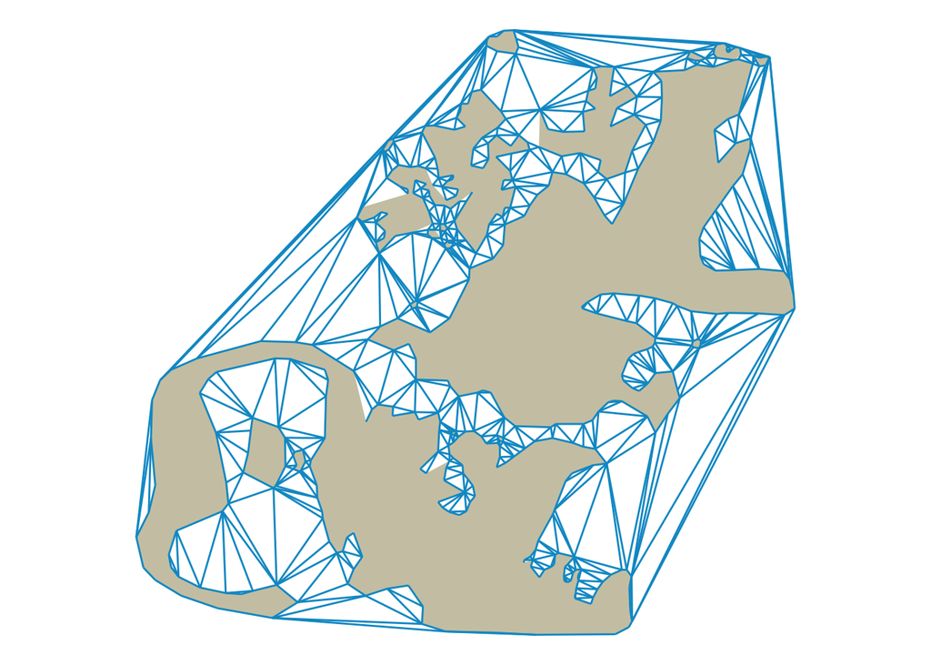

```r
tri_routes_noland <- st_read(con, "tri_routes_noland")
ggplot() +
  ggspatial::annotation_spatial(land_barrier, fill = "cornsilk3", size = 0) +
  ggspatial::layer_spatial(tri_routes_noland, color = "deepskyblue3") +
  theme_void()
```

Next up, we can select two random nodes from our network and calculate the shortest path based on the Djikstra algorithm. For this, we will pass the length of the edge as the cost so we are insured to get the shortest path not just the path with the minimal number of nodes. To check that we really have a working solution, we’ll run this query 1000 times.

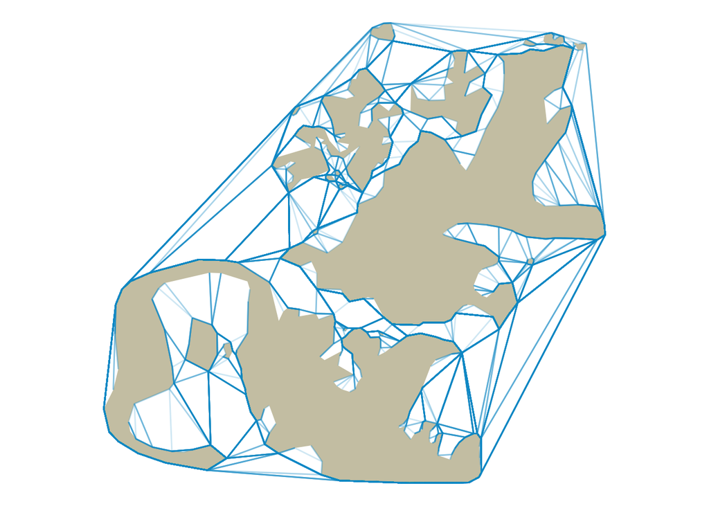

```r
sql_query <- "WITH rnd_source AS (select source from tri_routes_noland ORDER BY random() limit 1),
rnd_target AS (select target from tri_routes_noland ORDER BY random() limit 1)
SELECT seq, (select source from rnd_source) as source, (select target from rnd_target) as target, node, edge, cost as cost, geometry
FROM pgr_dijkstra(
'SELECT id, source, target, st_length(geometry) as cost, st_length(geometry) as reverse_cost FROM tri_routes_noland',
(SELECT source FROM rnd_source),(SELECT target FROM rnd_target), directed := FALSE) as pt
JOIN tri_routes_noland ON pt.edge = tri_routes_noland.id;"

rnd_shortpath <- function() {
  p <- st_read(dsn = con, query = sql_query)
  if(nrow(p) == 0) return(NULL)
  l <- p %>% summarise(do_union = FALSE) %>% st_line_merge()
  return(l)
}

path_list <- vector("list", 1000)

for(i in 1:length(path_list)) {
  path_list[[i]] <- rnd_shortpath()
}

shortpaths <- do.call(rbind, path_list)

ggplot() +
  ggspatial::annotation_spatial(land_barrier, fill = "cornsilk3", size = 0) +
  ggspatial::layer_spatial(shortpaths, color = "deepskyblue3", alpha = 0.2) +
  theme_void()
```

This seems to demonstrate that our approach is pretty robust. The next test is to test the routing between our points of interest (which are not nodes in our network). We could implement this entirely within the suite of PostGIS/pgRouting tools. But, here, we’ll take a hybrid approach where we rely on {sf} package to identify the nearest node to a given point of interest and, then, query the database for the shortest path.

The `pgr_shortpath()` function below is rather complicated, but it reflects the complexity involved in reliably determining the nearest node and also extending the network path to include the starting and ending points.

```r
pgr_shortpath <- function(data, con, tbl_edges, tbl_nodes = paste0(tbl_edges,"_vertices_pgr")) {
  nodes <- st_read(con, tbl_nodes)
  edges <- st_read(con, tbl_edges)
  start_pt <- data[1,]
  end_pt <- data[2,]

  start_edge <- st_nearest_feature(start_pt,edges)
  end_edge <- st_nearest_feature(end_pt, edges)

  start_nodes <- c(edges[start_edge, ]$source,
                   edges[start_edge, ]$target
  )

  end_nodes <- c(edges[end_edge, ]$source,
                   edges[end_edge, ]$target
  )

  start_node <- st_nearest_feature(start_pt, nodes[start_nodes,])
  start_node <- nodes[start_nodes, ][[start_node,"id"]]

  end_node <- st_nearest_feature(end_pt, nodes[end_nodes,])
  end_node <- nodes[end_nodes, ][[end_node,"id"]]

  sql <- glue::glue("
  SELECT seq, source, target, node, edge, cost as cost, geometry
  FROM pgr_dijkstra(
  'SELECT id, source, target, st_length(geometry) as cost,
  st_length(geometry) as reverse_cost FROM {tbl_edges}',
  {start_node},
  {end_node},
  directed := FALSE) as pt
JOIN {tbl_edges} ON pt.edge = {tbl_edges}.id
  ")

  p <- st_read(dsn = con, query = sql)
  if(nrow(p) == 0) return(NULL)

  l <- p %>% summarise(do_union = FALSE) %>% st_line_merge()
  start_idx <- st_nearest_feature(start_pt, c(st_startpoint(l), st_endpoint(l)))
  end_idx <- st_nearest_feature(end_pt, c(st_startpoint(l), st_endpoint(l)))
  l_start <- c(st_startpoint(l),st_endpoint(l))[start_idx,]
  l_end <- c(st_startpoint(l),st_endpoint(l))[end_idx,]

  l1 <- rbind(
    start_pt %>% st_cast('POINT'),
    l_start %>% st_sf()
  ) %>% summarise(do_union = FALSE) %>%
    st_cast('LINESTRING')
  l2 <- rbind(
    l_end %>% st_sf(),
    end_pt %>% st_cast('POINT')
  ) %>% summarise(do_union = FALSE) %>%
    st_cast('LINESTRING')

  l <- rbind(l1,l,l2) %>%
    summarise(do_union = FALSE) %>%
    st_cast('LINESTRING')

  return(l)
}
```

With our function established, we can test it by selecting 500 random pairs of points from our `poi` data set and returning the shortest path through our visibility graph. Initial benchmarking of this approach indicates about 56 seconds to solve all 500 paths.

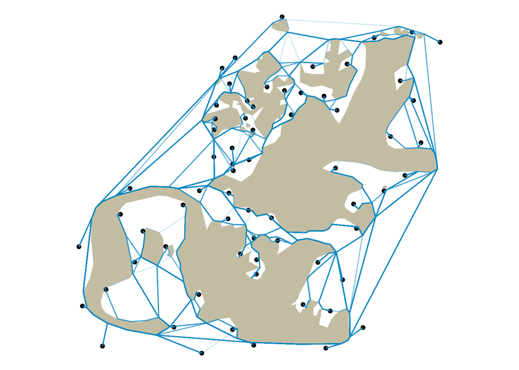

```r
random_ab_paths <- vector(mode = "list", length = 500L)

for (i in 1:length(random_ab_paths)) {
  random_ab_paths[[i]] <- poi %>%
  slice_sample(n = 2) %>%
  pgr_shortpath(con = con, tbl_edges = "tri_routes_noland")
}

paths <- do.call(rbind,random_ab_paths)

ggplot() +
  ggspatial::annotation_spatial(land_barrier, fill = "cornsilk3", size = 0) +
  ggspatial::layer_spatial(poi) +
  ggspatial::layer_spatial(paths, color = "deepskyblue3", alpha = 0.2) +
  theme_void()
```

## R implementation

Ok, now let’s try and make all of this work completely within R

```r
library(tidyverse)
library(sf)
library(lwgeom)
library(sfnetworks)
library(tidygraph)
library(ggspatial)
library(tictoc)
```

### spatial predicate functions

```r
not_within <- function(x,y) !st_within(x,y)
not_crosses <- function(x,y) !st_crosses(x,y)
```

A key component to creating our visual graph is the ability to remove lines/edges that cross our barrier polygon. the `sf::st_filter()` function cannot accept a negated spatial predicate (e.g. `!st_intersects()`). But, it can accept a custom predicate function. So, we create two here. `not_within()` will remove all of the lines that cross completely within a polygon from one node to another. Note, if a buffer value is passed to our `prt_visgraph()` function, this will likely not return any lines. The function `not_crosses()` handles the situation where an edge crosses over a portion of the barrier polygon

### identifying the nearest node

The `sfnetwork::spatial_shortest_path()` function will find the nearest nodes to a given set of start and end points and solve the shortest path based on those nodes. However, it is technically possible for the nearest node to not be associated with the nearest edge. This function is an attempt to address that …but, for now, we do not suggest implementing this as it dramatically increases the computation time and the potential impact on desired outcomes is negligible.

```r
prt_nearest_node <- function(n, p) {
  i <- st_nearest_feature(p, n %>% activate("edges"))
  edge <- n %>% activate("edges") %>%
    slice(i) %>% st_as_sf()
  nodes <- n %>% activate("nodes") %>%
    slice(c(edge$from, edge$to)) %>% st_as_sf()
  near_node <- st_nearest_feature(p, nodes)
  near_node <- edge[[1,near_node]]
}
```

### create a visibility graph

A few R packages exist for creating Delaunay Triangles across a landscape (`{deldir}`, `{anglr}`, `{geometry}`, `{RTriangle}`). For simplicity, we are starting with the `st_triangulate()` function that is included with the `{sf}` package. The other approaches may very well be more efficient, especially at even larger scales, and are worth further investigation. But, for now, the easy integration with typical `{sf}` workflows is a key benefit.

We are also relying on the `{sfnetwork}` package that is indevelopment and available on github. This package does much of the heavy lifting needed to translate between `{sf}` and `{igraph}` worlds and we are excited to see this package continue to develop and improve.

```r
prt_visgraph <- function(barrier, buffer = 0, centroids = TRUE, aug_points = NULL) {
  barrier <- st_union(
    st_cast(barrier, 'POLYGON')
  )

  if(buffer>0) {
    buf_poly <- barrier %>% st_buffer(buffer)
  } else {
    buf_poly <- barrier
  }

  if (centroids) {
  ctr_pts <- st_centroid(
    st_collection_extract(
    st_triangulate(
    st_cast(buf_poly, 'MULTIPOINT')
  ),
    'POLYGON')
  )

  edges <- c(
    buf_poly %>% st_cast('MULTIPOINT') %>% st_cast('POINT'),
    ctr_pts
    ) %>%
    st_union() %>%
    sf::st_triangulate(bOnlyEdges = TRUE) %>%
    sf::st_cast('LINESTRING') %>%
    sf::st_sf()%>%
    sf::st_filter(barrier, .predicate = not_within) %>%
    sf::st_filter(barrier, .predicate = not_crosses)
  }

  n <- sfnetworks::as_sfnetwork(edges, directed = FALSE) %>%
  activate("edges") %>%
  mutate(length = edge_length())

  return(n)
}
```

The visibility graph is created by removing all of the edges that cross land. For this, we’ll use our custom spatial predicate functions and filter those edges out of our graph. The final step is create our network via `as_sfnetwork()` function. It is critical that *directed = FALSE* be passed at this stage so that an undirected network is created. We also create a *length* column that represents edge length and will be used as our weight parameter when determining the shortest path between points.

### finding the shortest path

```r
prt_shortpath <- function(n, p1, p2) {

  p1 <- st_cast(p1, 'POINT')
  p2 <- st_cast(p2, 'POINT')

  # n1 <- prt_nearest_node(n, p1)
  # n2 <- prt_nearest_node(n, p2)

  l <- try(convert(n, to_spatial_shortest_paths,
                   p1, p2,
                   weights = "length"))

  if (length(st_geometry(l)) > 0) {
    l <- l %>% st_as_sf() %>%
      summarise(do_union = FALSE) %>%
      st_line_merge()
    start_idx <-
      st_nearest_feature(p1, c(st_startpoint(l), st_endpoint(l)))
    end_idx <-
      st_nearest_feature(p2, c(st_startpoint(l), st_endpoint(l)))
    l_start <- c(st_startpoint(l), st_endpoint(l))[start_idx, ]
    l_end <- c(st_startpoint(l), st_endpoint(l))[end_idx, ]

    l1 <- rbind(p1 %>% st_cast('POINT'),
                l_start %>% st_sf()) %>%
      summarise(do_union = FALSE) %>%
      st_cast('LINESTRING')

    l2 <- rbind(l_end %>% st_sf(),
                p2 %>% st_cast('POINT')) %>%
      summarise(do_union = FALSE) %>%
      st_cast('LINESTRING')

    l <- rbind(l1, l, l2) %>%
      summarise(do_union = FALSE) %>%
      st_line_merge()
  } else
    l <- NULL
  return(l)
}
```

The `prt_shortpath()` is built around the `spatial_shortest_paths()` function within the `{sfnetwork}` package. We access this function via the `convert()` morphing function in the `{tidygraph}` which returns a *‘LINESTRING’* that represents the shortest path along our visibility graph between the nodes nearest our specified start and end points. We need to do some additional investigation and manipulation (identify the nearest end points to the returned line and, then, create lines between those end points and our points) in order to return the complete path from start to end.

### simulated example

Let’s return to our example land barrier and our set of points of interest we used in the PostGIS/pgRouting example

```r
land_barrier <- sf::st_read(here::here('inst/extdata/simple_land_barrier.gpkg')) %>%
  st_transform(3338)
poi <- sf::st_read(here::here('inst/extdata/points_of_interest.gpkg')) %>%
  st_transform(3338)
```

We’ll take this land barrier and create a visual graph using our `prt_visgraph()` function and a buffer of 150 meters.

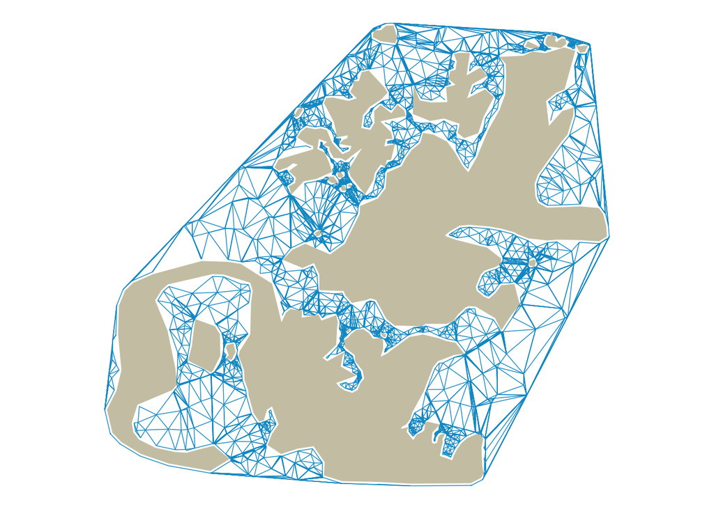

```r
vis_graph <- prt_visgraph(land_barrier, buffer = 150)

vis_graph_sf <- vis_graph %>% activate("edges") %>%
  st_as_sf()
ggplot() +
  ggspatial::annotation_spatial(data = land_barrier,
                                fill = "cornsilk3", size = 0) +
  ggspatial::layer_spatial(data = vis_graph_sf,
                           color = "deepskyblue3",
                           lwd = 0.25) +
  theme_void()
```

Next, we’ll draw a random sample of 500 pairs from our points of interest and calculate the shortest path between those points

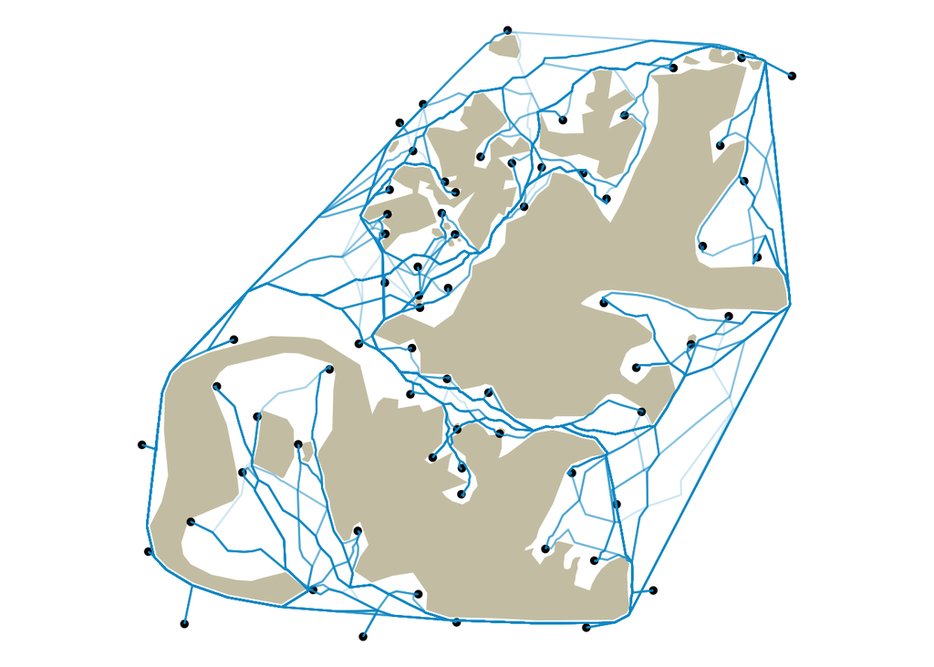

```r
# tic()
random_ab_paths <- vector(mode = "list", length = 500L)

for (i in 1:length(random_ab_paths)) {
  ab_points <- poi %>%
  slice_sample(n = 2)

  random_ab_paths[[i]] <-
    prt_shortpath(vis_graph, ab_points[1,], ab_points[2,])
}

paths <- do.call(rbind,random_ab_paths)
# toc()

ggplot() +
  ggspatial::annotation_spatial(land_barrier, fill = "cornsilk3", size = 0) +
  ggspatial::layer_spatial(poi) +
  ggspatial::layer_spatial(paths, color = "deepskyblue3", alpha = 0.2) +
  theme_void()
```